# FordGo Bike - Trip Data

### Overview:

- In this presentation we will do some invistigation for Ford GoBike System Dataset

### Dataset

This data set includes information about individual rides made in a bike-sharing system covering the greater San Francisco Bay area in **Feb2019**

> The dataset after cleaning contains 174952 trips with 17 features.

## Duration Distribution

### 1. Acual

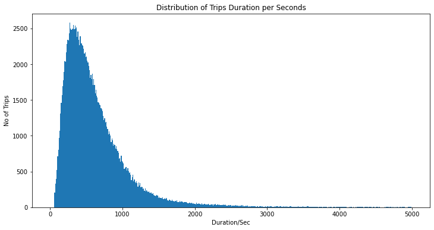

```python
# start with trip duration histogram
binsize = 10
xlim = 10000 / 2 # seconds
bins = np.arange(0, xlim+binsize, binsize)

plt.figure(figsize=(12, 6))
plt.hist(data = df, x = 'duration_sec', bins = bins)
#plt.xlim(0, xlim)
plt.title('Distribution of Trips Duration per Seconds')
plt.ylabel('No of Trips')
plt.xlabel('Duration/Sec')
plt.show()
```

**Would be better to use log scale instead of limitaions**

### 2. Scaled

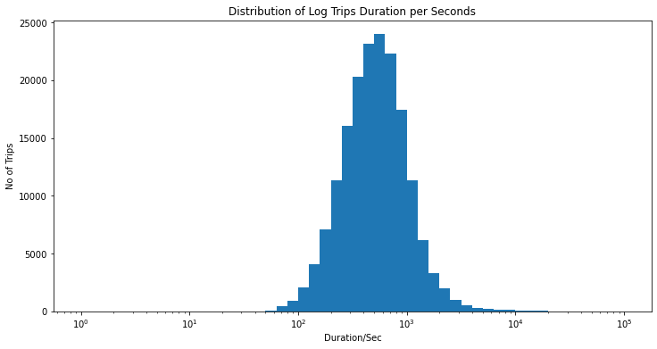

```python
# log trip duration histogram
bins = 10 ** np.arange(0, np.log10(df['duration_sec'].max())+0.1, 0.1)

plt.figure(figsize=(12, 6))
plt.hist(data = df, x = 'duration_sec', bins = bins)
plt.xscale('log')

plt.title('Distribution of Log Trips Duration per Seconds')
plt.ylabel('No of Trips')
plt.xlabel('Duration/Sec')
plt.show()
```

> **Distribution are symmetric with peak value at 500 second ~(about 8 minutes) which reasonable for a short rides.**

### Bikes Share and User Type

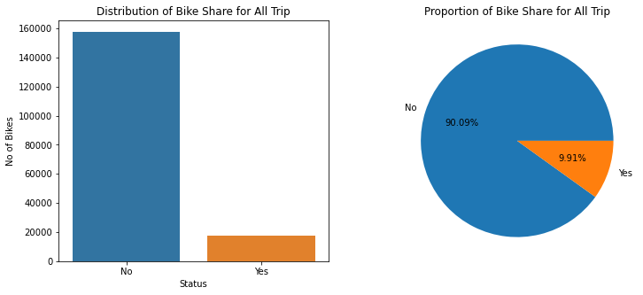

```python
# let's now show no of bike_share_for_all_trip

plt.figure(figsize=[12, 5])

plt.subplot(1, 2, 1)
sns.countplot(data = df, x = 'bike_share_for_all_trip')

plt.title('Distribution of Bike Share for All Trip')
plt.ylabel('No of Bikes')
plt.xlabel('Status')


plt.subplot(1, 2, 2)
plt.pie(bike_counts, labels = bike_counts.index, autopct='%1.2f%%')
plt.title('Proportion of Bike Share for All Trip')

plt.show()
```

> **The following figure show that +90% of users does not share the bikes for all trip.**

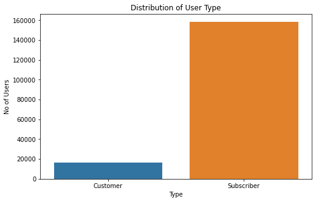

```python
# let's now show no of user_type

plt.figure(figsize=[8, 5])

sns.countplot(data = df, x = 'user_type')

plt.title('Distribution of User Type')
plt.ylabel('No of Users')
plt.xlabel('Type')

plt.show()
```

> **The following figure show that +90% of users are subscribers and only +9% are customers.**

### Start and End Stations

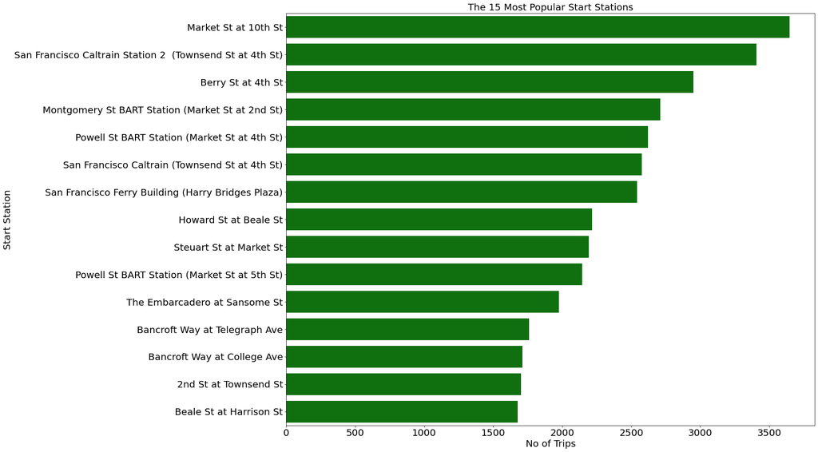

```python
# start staion
plt.figure(figsize=[20, 16])

sns.barplot(y=st_staions.index, x= st_staions, color='g')

plt.title('The 15 Most Popular Start Stations', fontsize=20)
plt.ylabel('Start Station', fontsize=20)
plt.xlabel('No of Trips', fontsize=20)

plt.xticks(fontsize=20)
plt.yticks(fontsize=20)

plt.show()
```

> **The avarage No. of trips between Top-15 start staion is +1.5K trip, and most strat station has +3.5K trip this month (Feb2019)**

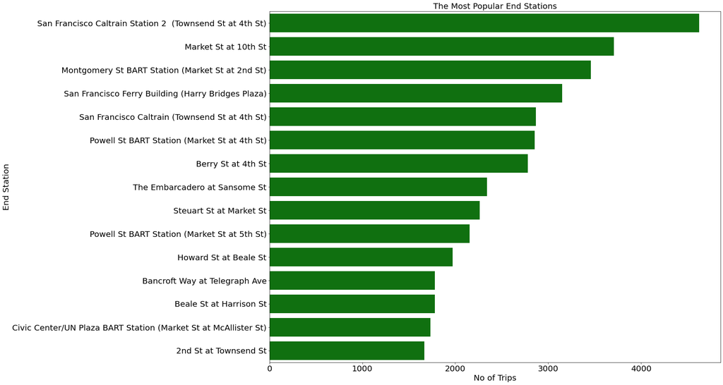

```python
# end staion
plt.figure(figsize=[20, 16])

sns.barplot(y=end_staions.index, x= end_staions, color='g')

plt.title('The Most Popular End Stations', fontsize=20)
plt.ylabel('End Station', fontsize=20)
plt.xlabel('No of Trips', fontsize=20)

plt.xticks(fontsize=20)
plt.yticks(fontsize=20)

plt.show()
```

> **The avarage No. of trips between Top-15 end staion is +1K trip, and most end station has +4K trip this month (Feb2019)**

### Gender

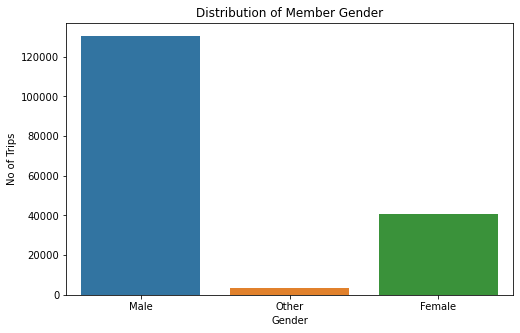

```python
# let's now show no of user_type

plt.figure(figsize=[8, 5])

sns.countplot(data = df, x = 'member_gender')

plt.title('Distribution of Member Gender')
plt.ylabel('No of Trips')
plt.xlabel('Gender')

plt.show()
```

> **The figure show that most user are men with No. of trips exceed +120K. Female has made +40K trips this month**

## Age

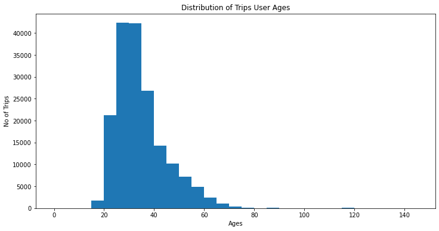

```python
# start with trip duration histogram
binsize = 5
bins = np.arange(0, df['age'].max()+binsize, binsize)

plt.figure(figsize=(12, 6))
plt.hist(data = df, x = 'age', bins = bins)
plt.title('Distribution of Trips User Ages')
plt.ylabel('No of Trips')
plt.xlabel('Ages')
plt.show()
```

> **Most of user ages between 20-60 years old. with peak +40K trip for users who has 30-35 year.**

### Station Locations

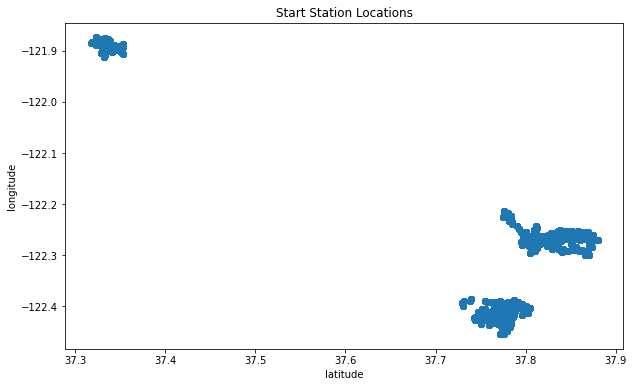

```python
# start staions location

plt.figure(figsize=(10, 6))
plt.scatter(data=df, x='start_station_latitude', y='start_station_longitude');

plt.title("Start Station Locations")

plt.xlabel('latitude')
plt.ylabel('longitude')

plt.show()
```

> **Most of strater staions can be converted into 3 main clusters (Location)**

### Days and Day of Week

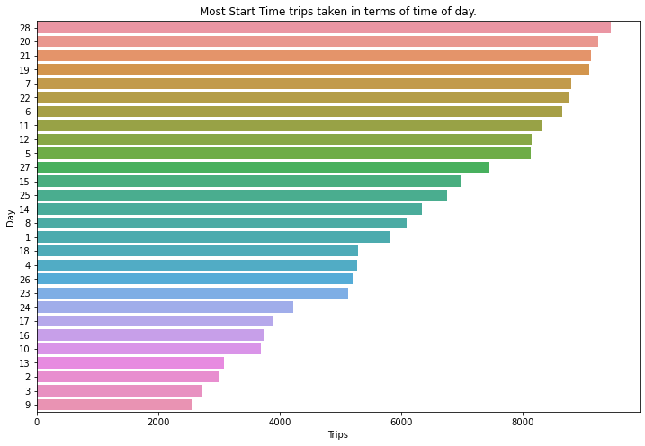

```python
# start time day
days_count = df.start_day.value_counts()

plt.figure(figsize=(12, 8))
sns.countplot(data=df, y='start_day', order=days_count.index);

plt.title('Most Start Time trips taken in terms of time of day.')
plt.xlabel('Trips')
plt.ylabel('Day')

plt.show()
```

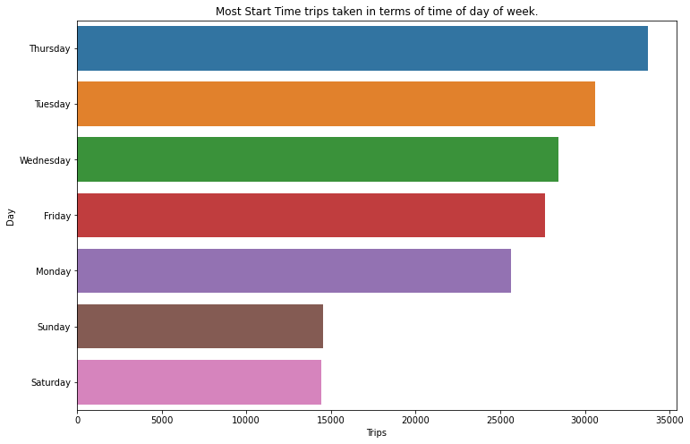

```python
# start time day of week
days_count = df.start_week.value_counts()

plt.figure(figsize=(12, 8))
sns.countplot(data=df, y='start_week', order=days_count.index);

plt.title('Most Start Time trips taken in terms of time of day of week.')
plt.xlabel('Trips')
plt.ylabel('Day')

plt.show()
```

## Data Correlations

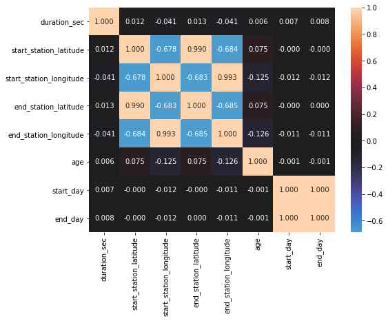

```python
# lets now display the correlation between variables using heatmap
plt.figure(figsize = [8, 6])
corr = df.corr()
sns.heatmap(corr,
            annot = True,
            fmt = '.3f',
            center = 0)
plt.show()
```

> **Strong correlation appearance between similar type features like locations and dates. and low correlation between other features**

### **Relation between Duration, Age and Gender?**

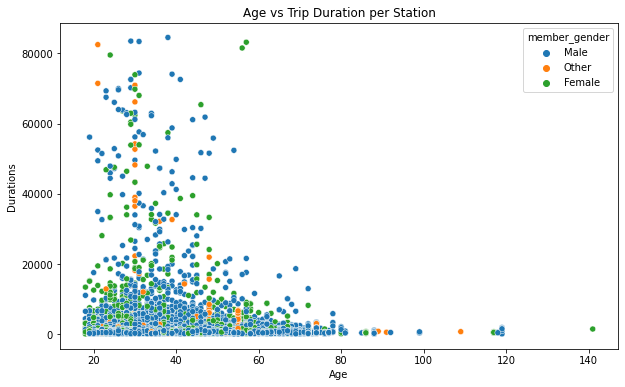

```python
plt.figure(figsize=(10, 6))
sns.scatterplot(data=df, x='age', y='duration_sec', hue='member_gender')
plt.xlabel('Age')
plt.ylabel('Durations')
plt.title('Age vs Trip Duration per Station')
plt.show()
```

> **Most distribution consist from mid age users, high duration does not depend on gender because all genders exist at the top of plot.**

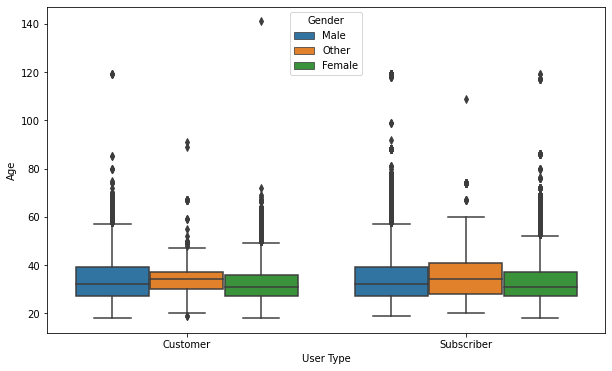

```python
# let's get the relation between age, gender, user type
plt.figure(figsize=(10, 6))

sns.boxplot(data = df, x = 'user_type',  y = 'age', hue='member_gender')

plt.legend(title="Gender")
plt.xlabel("User Type")
plt.ylabel("Age")
plt.show()
```

> **Range (variance) of subscribers are slightly larger than customers.**

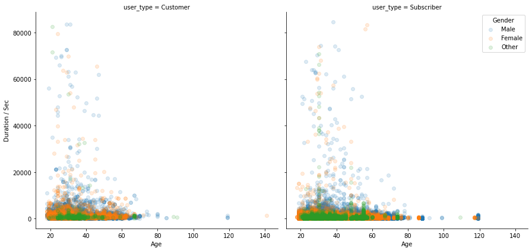

```python
# let's display the relation between duration, age, user type, gender feature
# create faceted heat maps on the user type variable
graph = sns.FacetGrid(data = df,
                      col = 'user_type',
                      hue='member_gender',
                      hue_order=['Male','Female','Other'],
                      col_wrap = 6, height = 6
                     )

graph.map(plt.scatter, 'age', 'duration_sec', alpha=0.15)
graph.set_xlabels('Age')
graph.set_ylabels('Duration / Sec')
plt.legend(title="Gender")
plt.show()
```

### Station Latitude and Longitude (Locations) Relationships.

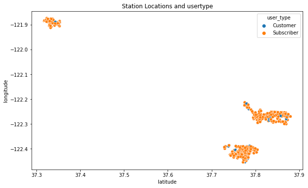

```python
### Station Latitude and Longitude and UserType

plt.figure(figsize=(10, 6))
sns.scatterplot(data=df,
                x='start_station_latitude',
                y='start_station_longitude',
                hue='user_type');

plt.title("Station Locations and usertype")

plt.xlabel('latitude')
plt.ylabel('longitude')

plt.show()
```

> **Subscriber users spread across the 3 main staions locations (clusters), there is few customer users existing in the upper right cluster.**

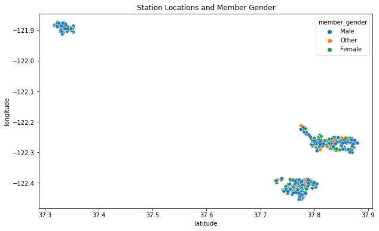

```python
### Station Latitude and Longitude and member_gender

plt.figure(figsize=(10, 6))
sns.scatterplot(data=df,
                x='start_station_latitude',
                y='start_station_longitude',
                hue='member_gender');

plt.title("Station Locations and Member Gender")

plt.xlabel('latitude')
plt.ylabel('longitude')

plt.show()
```

> **Male uses the 3 main locations (clusters) more than Females.**

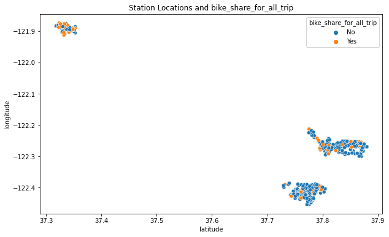

```python
### Station Latitude and Longitude and bike_share_for_all_trip

plt.figure(figsize=(10, 6))
sns.scatterplot(data=df,
                x='start_station_latitude',
                y='start_station_longitude',
                hue='bike_share_for_all_trip');

plt.title("Station Locations and bike_share_for_all_trip")

plt.xlabel('latitude')
plt.ylabel('longitude')

plt.show()
```

> **User who started thire journey from the left cluster are more likely to share bike for all trip than users who use bikes from both right locations.**

### Conclusions:

- High duration trips does not related to gender but and most trips consist of mid age users.
- Age range of subscribers user type are slightly larger than customers.
- Subscriber users uses the 3 main staions locations more than other users types.
- Male spread on the 3 main locations (clusters) more than Females.
- User who started thire journey from the left cluster are more likely to share bike for all trip than users who use bikes from both right locations.